# DNA/RNA project module II - Analysis of DNA methylation data

Valentina Benatti, Vera Bianco, Antonio Pilato, Vittorio Galletta, Leonardo Del Mastio, Giacomo Tassinari, Niccolò Lenzi

2026-06-30

### 1. Raw data loading via minfi

In this initial step, the R environment is prepared by clearing the workspace and setting the working directory. After ensuring that the necessary packages are installed and loaded, we import the cleaned Illumina 450K manifest file which contains probe informations. Finally, the sample sheet information is parsed from the data directory, and the raw IDAT files are loaded into an RGChannelSet object (named RGset) to store the raw Red and Green fluorescence intensities for each physical address on the microarray.

```r
# Clear the environment to start with a clean state
rm(list=ls())

#set your correct working directory:
setwd("~/progetto_DNA_RNA/")

# Install necessary libraries if they are missing (conditional to prevent knitting errors)
if (!requireNamespace("minfi", quietly = TRUE)) BiocManager::install("minfi", ask = FALSE)
if (!requireNamespace("IlluminaHumanMethylation450kmanifest", quietly = TRUE)) BiocManager::install("IlluminaHumanMethylation450kmanifest", ask = FALSE)
if (!requireNamespace("IlluminaHumanMethylation450kanno.ilmn12.hg19", quietly = TRUE)) BiocManager::install("IlluminaHumanMethylation450kanno.ilmn12.hg19", ask = FALSE)
if (!requireNamespace("factoextra", quietly = TRUE)) install.packages("factoextra", repos = "https://cloud.r-project.org")
if (!requireNamespace("qqman", quietly = TRUE)) install.packages("qqman", repos = "https://cloud.r-project.org")
if (!requireNamespace("gplots", quietly = TRUE)) install.packages("gplots", repos = "https://cloud.r-project.org")

# Load the required libraries
library(minfi)
library(IlluminaHumanMethylation450kmanifest)
library(IlluminaHumanMethylation450kanno.ilmn12.hg19)
library(factoextra)
library(qqman)
library(gplots)

# Load the cleaned Illumina 450K manifest file containing probe annotations
baseDir <- "Input_Data"

load("Illumina450Manifest_clean.RData")


# Read the sample sheet containing metadata and sample information
targets <- read.metharray.sheet(baseDir)
```

```
## [1] "Input_Data/SampleSheet_Report_II.csv"
```

```r
# Creates a RGChannelSet which stores the raw Red and Green light intensities for each physical Address on the microarray
RGset <- read.metharray.exp(targets = targets)

# T explore the RGset object:
# RGset
```

### 2. Red and Green Channels Extraction

To store the fluorescence intensities separately, we extract the Red and Green channels from the RGset object using the getRed() and getGreen() functions, respectively. These values represent the raw signal intensities measured by the Illumina scanner for each sample across the array before any preprocessing or normalization step. The extracted matrices are then converted into two distinct dataframes.

```r
# Create a dataframe containing the Red fluorescence intensities extracted from RGset
Red <- data.frame(getRed(RGset))
# Check the dimension and the first rows of the object
dim(Red)
```

```
## [1] 622399      8
```

```r
head(Red)
```

|  | GSM5319592_200121140049_R01C02 | GSM5319603_3999356129_R02C02 | GSM5319604_3999547012_R02C01 | GSM5319607_3999547012_R03C02 | GSM5319609_3999547016_R02C01 | GSM5319613_3999547017_R02C01 | GSM5319615_3999547017_R04C01 | GSM5319616_3999547017_R06C01 |
| --- | --- | --- | --- | --- | --- | --- | --- | --- |
| 10600313 | 322 | 159 | 303 | 419 | 294 | 346 | 523 | 491 |
| 10600322 | 361 | 231 | 553 | 919 | 127 | 731 | 943 | 574 |
| 10600328 | 1522 | 469 | 1682 | 2301 | 1163 | 1085 | 1708 | 1250 |
| 10600336 | 4916 | 3034 | 9117 | 13823 | 2664 | 10864 | 12023 | 11925 |
| 10600345 | 875 | 252 | 1168 | 1326 | 457 | 1828 | 2138 | 899 |
| 10600353 | 596 | 205 | 556 | 860 | 477 | 444 | 632 | 478 |

```r
# Create a dataframe containing the Green fluorescence intensities extracted from RGset
Green <- data.frame(getGreen(RGset))
# Check the dimension and the first rows of the object
dim(Green)
```

```
## [1] 622399      8
```

```r
head(Green)
```

|  | GSM5319592_200121140049_R01C02 | GSM5319603_3999356129_R02C02 | GSM5319604_3999547012_R02C01 | GSM5319607_3999547012_R03C02 | GSM5319609_3999547016_R02C01 | GSM5319613_3999547017_R02C01 | GSM5319615_3999547017_R04C01 | GSM5319616_3999547017_R06C01 |
| --- | --- | --- | --- | --- | --- | --- | --- | --- |
| 10600313 | 134 | 53 | 124 | 198 | 133 | 157 | 146 | 146 |
| 10600322 | 3109 | 1160 | 3546 | 5033 | 694 | 4135 | 4955 | 3743 |
| 10600328 | 1764 | 669 | 2246 | 2497 | 1820 | 1229 | 1827 | 1645 |
| 10600336 | 566 | 336 | 873 | 1279 | 275 | 804 | 1012 | 986 |
| 10600345 | 1558 | 277 | 1147 | 1555 | 558 | 2103 | 2053 | 1323 |
| 10600353 | 1903 | 476 | 1967 | 1994 | 1632 | 1595 | 2719 | 1889 |

### 3. Single Probe Intensity Analysis (Address 67790505)

We extracted the raw fluorescence intensities corresponding to the specific address ID assigned to Group 3, namely 67790505. The Illumina HumanMethylation450 manifest was queried to retrieve the annotation details associated with the selected address. The query revealed that the address corresponds to an Infinium Type I probe design. Since Type I probes utilize two distinct bead addresses operating within a single color channel (either Red or Green) to interrogate the methylated and unmethylated states, the manifest was further queried to report the specific color channel assigned to this probe (Red).

```r
# Extract the Red fluorescence values for the address assigned to Group 3
Red['67790505', ]
```

|  | GSM5319592_200121140049_R01C02 | GSM5319603_3999356129_R02C02 | GSM5319604_3999547012_R02C01 | GSM5319607_3999547012_R03C02 | GSM5319609_3999547016_R02C01 | GSM5319613_3999547017_R02C01 | GSM5319615_3999547017_R04C01 | GSM5319616_3999547017_R06C01 |
| --- | --- | --- | --- | --- | --- | --- | --- | --- |
| 67790505 | 120 | 70 | 1328 | 241 | 592 | 1798 | 2352 | 1216 |

```r
# Extract the Green fluorescence values for the address assigned to Group 3
Green['67790505', ]
```

|  | GSM5319592_200121140049_R01C02 | GSM5319603_3999356129_R02C02 | GSM5319604_3999547012_R02C01 | GSM5319607_3999547012_R03C02 | GSM5319609_3999547016_R02C01 | GSM5319613_3999547017_R02C01 | GSM5319615_3999547017_R04C01 | GSM5319616_3999547017_R06C01 |
| --- | --- | --- | --- | --- | --- | --- | --- | --- |
| 67790505 | 119 | 63 | 175 | 188 | 125 | 168 | 245 | 200 |

```r
# Check in the manifest whether the selected address corresponds to a Type I or Type II probe
Type <- Illumina450Manifest_clean[
  Illumina450Manifest_clean$AddressA_ID == 67790505 | Illumina450Manifest_clean$AddressB_ID == 67790505,
  'Infinium_Design_Type'
]
Type
```

```
## [1] I
## Levels: I II
```

```r
# Check in the manifest the color channel of the selected probe
Color <- Illumina450Manifest_clean[
  Illumina450Manifest_clean$AddressA_ID == 67790505 | Illumina450Manifest_clean$AddressB_ID == 67790505,
  'Color_Channel'
]
Color
```

```
## [1] Red
## Levels:  Grn Red
```

```r
# Create the final table with Red fluorescence, Green fluorescence, probe type and color channel
data <- data.frame(
  Red = as.numeric(Red['67790505', ]),
  Green = as.numeric(Green['67790505', ]),
  Type = Type,
  Color = Color
)

# Assign sample names as row names of the table
row.names(data) <- colnames(Red)

# Print the final table for Step 3
data
```

|  | Red | Green | Type | Color |
| --- | --- | --- | --- | --- |
| GSM5319592_200121140049_R01C02 | 120 | 119 | I | Red |
| GSM5319603_3999356129_R02C02 | 70 | 63 | I | Red |
| GSM5319604_3999547012_R02C01 | 1328 | 175 | I | Red |
| GSM5319607_3999547012_R03C02 | 241 | 188 | I | Red |
| GSM5319609_3999547016_R02C01 | 592 | 125 | I | Red |
| GSM5319613_3999547017_R02C01 | 1798 | 168 | I | Red |
| GSM5319615_3999547017_R04C01 | 2352 | 245 | I | Red |
| GSM5319616_3999547017_R06C01 | 1216 | 200 | I | Red |

### 4. Create the object MSet.raw

The raw intensity data from the RGChannelSet (RGset) is converted into a MethylSet object (MSet.raw) using the preprocessRaw() function. This function maps the raw physical address fluorescence (Red and Green channels) to their corresponding biological CpG sites based on the Illumina manifest. It generates two distinct matrices representing the Methylated (M) and Unmethylated (U) signal intensities for each probe, without applying any background correction or normalization. This object serves as the baseline raw dataset for subsequent quality control and normalization procedures.

```r
MSet.raw <- preprocessRaw(RGset)
```

### 5. Quality Control and Sample Reliability Assessment

Before diving into the actual analysis, we run a data quality control (QC) check to make sure the samples and probes are reliable. First, we calculate and plot the median intensities of the methylated (M) and unmethylated (U) signals for each sample; this helps to identify potential outliers: - The QC plot shows that only three samples pass the optimal quality threshold (black circles), while five samples (numbered in red) show lower-than-expected signal intensities.

Finally, detection p-values are calculated for each probe across all samples; probes with a detection p-value greater than the conventional threshold of 0.05 are flagged as unreliable (failed) measurements. Summarizing the number of passed and failed probes provides a comprehensive overview of the overall hybridization quality across the dataset.

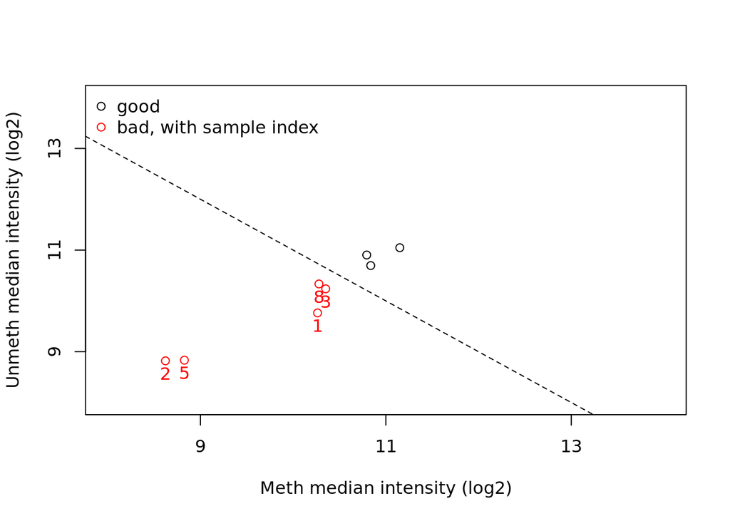

```r
# Estimate sample-specific QC medians (M and U) and plot them to identify outlier samples
qc <- getQC(MSet.raw)
plotQC(qc)
```

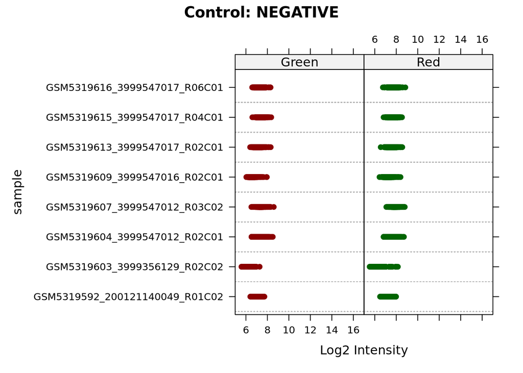

```r
# Plot the intensity of negative control probes to evaluate the background noise level across samples
controlStripPlot(RGset, control="NEGATIVE")
```

```r
# Calculate detection p-values for each probe across all samples
detP <- detectionP(RGset)

# Flag probes as 'TRUE' if their p-value is above 0.05, meaning they are NOT statistically significant
failed <- detP>0.05

# Examine the distribution of p-values and look at the logical matrix preview
summary(detP)
```

```
##  GSM5319592_200121140049_R01C02 GSM5319603_3999356129_R02C02
##  Min.   :0.0000000              Min.   :0.0000000
##  1st Qu.:0.0000000              1st Qu.:0.0000000
##  Median :0.0000000              Median :0.0000000
##  Mean   :0.0001504              Mean   :0.0002087
##  3rd Qu.:0.0000000              3rd Qu.:0.0000000
##  Max.   :1.0000000              Max.   :1.0000000
##  GSM5319604_3999547012_R02C01 GSM5319607_3999547012_R03C02
##  Min.   :0.00000              Min.   :0.0000000
##  1st Qu.:0.00000              1st Qu.:0.0000000
##  Median :0.00000              Median :0.0000000
##  Mean   :0.00096              Mean   :0.0002357
##  3rd Qu.:0.00000              3rd Qu.:0.0000000
##  Max.   :1.00000              Max.   :1.0000000
##  GSM5319609_3999547016_R02C01 GSM5319613_3999547017_R02C01
##  Min.   :0.00000              Min.   :0.0000000
##  1st Qu.:0.00000              1st Qu.:0.0000000
##  Median :0.00000              Median :0.0000000
##  Mean   :0.00179              Mean   :0.0004461
##  3rd Qu.:0.00000              3rd Qu.:0.0000000
##  Max.   :1.00000              Max.   :1.0000000
##  GSM5319615_3999547017_R04C01 GSM5319616_3999547017_R06C01
##  Min.   :0.0000000            Min.   :0.0000000
##  1st Qu.:0.0000000            1st Qu.:0.0000000
##  Median :0.0000000            Median :0.0000000
##  Mean   :0.0003677            Mean   :0.0005401
##  3rd Qu.:0.0000000            3rd Qu.:0.0000000
##  Max.   :1.0000000            Max.   :1.0000000
```

```r
head(failed)
```

```
##            GSM5319592_200121140049_R01C02 GSM5319603_3999356129_R02C02
## cg00050873                          FALSE                        FALSE
## cg00212031                          FALSE                        FALSE
## cg00213748                          FALSE                        FALSE
## cg00214611                          FALSE                        FALSE
## cg00455876                          FALSE                        FALSE
## cg01707559                          FALSE                        FALSE
##            GSM5319604_3999547012_R02C01 GSM5319607_3999547012_R03C02
## cg00050873                        FALSE                        FALSE
## cg00212031                         TRUE                        FALSE
## cg00213748                        FALSE                        FALSE
## cg00214611                         TRUE                        FALSE
## cg00455876                        FALSE                        FALSE
## cg01707559                        FALSE                        FALSE
##            GSM5319609_3999547016_R02C01 GSM5319613_3999547017_R02C01
## cg00050873                        FALSE                        FALSE
## cg00212031                        FALSE                        FALSE
## cg00213748                         TRUE                         TRUE
## cg00214611                         TRUE                         TRUE
## cg00455876                        FALSE                        FALSE
## cg01707559                        FALSE                        FALSE
##            GSM5319615_3999547017_R04C01 GSM5319616_3999547017_R06C01
## cg00050873                         TRUE                        FALSE
## cg00212031                         TRUE                        FALSE
## cg00213748                         TRUE                         TRUE
## cg00214611                         TRUE                         TRUE
## cg00455876                        FALSE                        FALSE
## cg01707559                        FALSE                        FALSE
```

```r
# Count the number of passed (FALSE) and failed (TRUE) probes for each sample
output <- apply(failed, 2, table)
output
```

```
##       GSM5319592_200121140049_R01C02 GSM5319603_3999356129_R02C02
## FALSE                         485310                       485206
## TRUE                             202                          306
##       GSM5319604_3999547012_R02C01 GSM5319607_3999547012_R03C02
## FALSE                       484356                       485146
## TRUE                          1156                          366
##       GSM5319609_3999547016_R02C01 GSM5319613_3999547017_R02C01
## FALSE                       482777                       485052
## TRUE                          2735                          460
##       GSM5319615_3999547017_R04C01 GSM5319616_3999547017_R06C01
## FALSE                       485128                       484838
## TRUE                           384                          674
```

### 6. Calculate raw beta and M values and plot the densities of mean methylation values

The first step involves extracting the Beta and M-values from the dataset using the getBeta() and getM() functions provided by the minfi package. The Beta-values are converted into a data frame and partitioned into control (CTRL) and disease (DIS) groups based on the phenotypic information contained in the targets metadata. We then compute the density distribution of the average Beta-value per probe within each phenotype. Overlaying these distributions in a single plot, with CTRL in green and DIS in purple, allows for a quick visual assessment of macroscopic shifts in global methylation between the two groups.

```r
# extracting Beta and M values
beta <- getBeta(MSet.raw)
M <- getM(MSet.raw)

# Create a data.frame
beta_df <- data.frame(beta)

#filtering the columns of the data frame based on the information contained in the dataframe 'targets'.
#control group (CTRL)
beta_df_control <- beta_df[, targets$Group=='CTRL']

# checking how many samples and probes we have
dim(beta_df_control)
```

```
## [1] 485512      4
```

```r
#disease group (DIS)
beta_df_disease <- beta_df[, targets$Group=='DIS']

# checking how many samples and probes we have
dim(beta_df_disease)
```

```
## [1] 485512      4
```

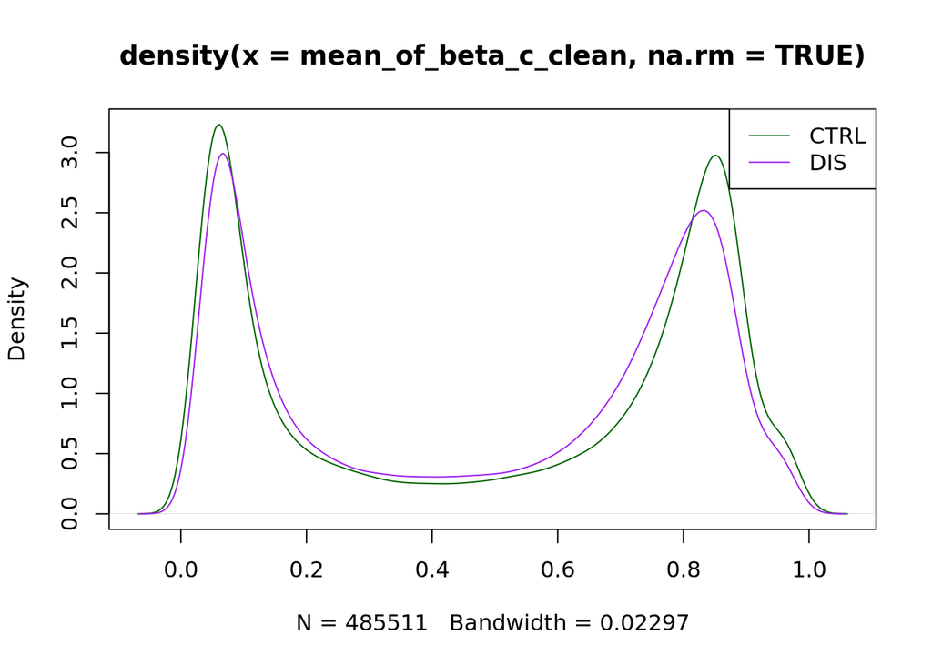

```r
# Calculate the mean Beta-value for each probe across samples within each group and plotting
mean_of_beta_c <- apply(beta_df_control, 1, mean, na.rm=TRUE)
mean_of_beta_d <- apply(beta_df_disease, 1, mean, na.rm=TRUE)
mean_of_beta_c_clean <- na.omit(mean_of_beta_c)
mean_of_beta_d_clean <- na.omit(mean_of_beta_d)

#density check
density_control <- density(mean_of_beta_c_clean, na.rm = TRUE)
density_disease <- density(mean_of_beta_d_clean, na.rm = TRUE)

#plot of the density of mean methylation values, dividing the samples in CTRL and DIS
plot(density_control, col='darkgreen')
lines(density_disease, col='purple')
legend("topright", legend = c("CTRL", "DIS"), col = c("darkgreen","purple"), lty = 1)
```

The overlay density plot of mean Beta-values shows the characteristic bimodal distribution of DNA methylation across the analyzed probes. The first peak represents the unmethylated fraction of the genome, while the second corresponds to highly methylated regions. Comparing the two groups reveals a shift in the global methylation profile of the disease group (DIS, purple line) relative to the healthy controls (CTRL, green line). Specifically, the disease profile shows a lower methylated peak and an increased density in the intermediate semi-methylated range, indicating widespread global hypomethylation in the disease phenotype. Conversely, both groups maintain a similar baseline for the unmethylated state, despite a minor decrease in peak sharpness for the disease samples.

### 7. Data Normalization and Probe Chemistry Evaluation

To normalize the dataset and evaluate the impact of probe chemistry (Infinium Type I vs. Type II), we apply the Quantile Normalization method (preprocessQuantile). This approach corrects technical biases and standardizes distributions across samples. To assess the efficiency of the procedure, mean beta values, standard deviations, and global distributions are calculated and compared both before and after normalization, providing a side-by-side diagnostic visualization.

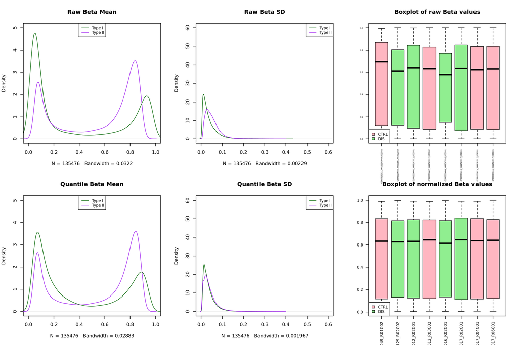

```r
# Subset the manifest into Type I (dfI) and Type II (dfII) probes based on their chemistry
dfI <- Illumina450Manifest_clean[Illumina450Manifest_clean$Infinium_Design_Type == "I", ]
dfI <- droplevels(dfI)
dfII <- Illumina450Manifest_clean[Illumina450Manifest_clean$Infinium_Design_Type == "II", ]
dfII <- droplevels(dfII)

# Separation raw beta values according to probe chemistry (Type I vs Type II)
beta_I <- beta[rownames(beta) %in% dfI$IlmnID, ]
beta_II <- beta[rownames(beta) %in% dfII$IlmnID, ]

# Calculate mean, standard deviation and their densities for raw data
mean_of_beta_I <- apply(beta_I, 1, mean, na.rm = TRUE)
mean_of_beta_II <- apply(beta_II, 1, mean, na.rm = TRUE)
d_mean_of_beta_I <- density(mean_of_beta_I, na.rm = TRUE)
d_mean_of_beta_II <- density(mean_of_beta_II, na.rm = TRUE)

sd_of_beta_I <- apply(beta_I, 1, sd, na.rm = TRUE)
sd_of_beta_II <- apply(beta_II, 1, sd, na.rm = TRUE)
d_sd_of_beta_I <- density(sd_of_beta_I, na.rm = TRUE)
d_sd_of_beta_II <- density(sd_of_beta_II, na.rm = TRUE)

# Apply Quantile Normalization to correct technical biases and standardize distributions
preprocessQuantile_results <- preprocessQuantile(RGset)

# Extract normalized beta values from their GenomicRatioSet
beta_preprocessQuantile <- getBeta(preprocessQuantile_results)

# Separate normalized beta values according to probe chemistry
beta_preprocessQuantile_I <- beta_preprocessQuantile[rownames(beta_preprocessQuantile) %in% dfI$IlmnID, ]
beta_preprocessQuantile_II <- beta_preprocessQuantile[rownames(beta_preprocessQuantile) %in% dfII$IlmnID, ]

# Calculate mean, standard deviation and their densities for normalized data
mean_of_beta_preprocessQuantile_I <- apply(beta_preprocessQuantile_I, 1, mean, na.rm = TRUE)
mean_of_beta_preprocessQuantile_II <- apply(beta_preprocessQuantile_II, 1, mean, na.rm = TRUE)
d_mean_of_beta_preprocessQuantile_I <- density(mean_of_beta_preprocessQuantile_I, na.rm = TRUE)
d_mean_of_beta_preprocessQuantile_II <- density(mean_of_beta_preprocessQuantile_II, na.rm = TRUE)

sd_of_beta_preprocessQuantile_I <- apply(beta_preprocessQuantile_I, 1, sd, na.rm = TRUE)
sd_of_beta_preprocessQuantile_II <- apply(beta_preprocessQuantile_II, 1, sd, na.rm = TRUE)
d_sd_of_beta_preprocessQuantile_I <- density(sd_of_beta_preprocessQuantile_I, na.rm = TRUE)
d_sd_of_beta_preprocessQuantile_II <- density(sd_of_beta_preprocessQuantile_II, na.rm = TRUE)

# Convert the 'Group' column to a factor for grouping and coloring purposes
targets$Group <- as.factor(targets$Group)

# Define a custom color palette for the groups (CTRL and DIS)
palette(c("lightpink", "lightgreen"))

# Set up the layout: 2 rows (Raw vs Normalized) and 3 columns (Mean, SD, Boxplot)
par(mfrow = c(2, 3))

# Panel 1: Density of raw mean beta values
plot(d_mean_of_beta_I, col = "darkgreen", main = "Raw Beta Mean", xlim = c(0, 1), ylim = c(0, 5))
lines(d_mean_of_beta_II, col = "purple")
legend("top", legend = c("Type I", "Type II"), col = c("darkgreen", "purple"), lty = 1, cex = 0.8)


# Panel 2: Density of raw standard deviation beta values
plot(d_sd_of_beta_I, col = "darkgreen", main = "Raw Beta SD", xlim = c(0, 0.6), ylim = c(0, 60))
lines(d_sd_of_beta_II, col = "purple")
legend("topright", legend = c("Type I", "Type II"), col = c("darkgreen", "purple"), lty = 1, cex = 0.8)

# Panel 3: Boxplot of raw beta values (colored by CTRL and DIS groups)
boxplot(beta, col = targets$Group, main = "Boxplot of raw Beta values", las = 2, cex.axis = 0.4)
legend("bottomleft", legend = levels(targets$Group), fill = palette(), cex = 0.8)

# Panel 4: Density of normalized mean beta values
plot(d_mean_of_beta_preprocessQuantile_I, col = "darkgreen", main = "Quantile Beta Mean", xlim = c(0, 1), ylim = c(0, 5))
lines(d_mean_of_beta_preprocessQuantile_II, col = "purple")
legend("top", legend = c("Type I", "Type II"), col = c("darkgreen", "purple"), lty = 1, cex = 0.8)


# Panel 5: Density of normalized standard deviation beta values
plot(d_sd_of_beta_preprocessQuantile_I, col = "darkgreen", main = "Quantile Beta SD", xlim = c(0, 0.6), ylim = c(0, 60))
lines(d_sd_of_beta_preprocessQuantile_II, col = "purple")
legend("topright", legend = c("Type I", "Type II"), col = c("darkgreen", "purple"), lty = 1, cex = 0.8)

# Panel 6: Boxplot of normalized beta values (colored by CTLR and DIS groups)
boxplot(beta_preprocessQuantile, col = targets$Group, main = "Boxplot of normalized Beta values",
las = 2, cex.axis = 0.8)
legend("bottomleft", legend = levels(targets$Group), fill = palette(), cex = 0.8)
```

```r
# Reset par setting default (1 row, 1 column) to avoid affecting subsequent plots in the markdown
par(mfrow = c(1, 1))
```

This normalization approach is appropriate in this specific dataset, because we do not expect extreme or widespread biological changes across the entire genome. Since our data fits this assumption, we can safely force all samples to share the same general distribution. This process removes technical noise caused by lab equipment or processing differences, ensuring that any differences spotted later on specific genes represent real biological changes rather than measurement errors.

### 8. Unsupervised Dimensionality Reduction via PCA

Principal Component Analysis, or PCA, is an unsupervised dimensionality reduction method. We apply PCA when we have high-dimensional data, such as thousands of genes measured across many samples, and we want to summarize the main sources of variability in fewer dimensions. PCA transforms the original variables into new variables called principal components. The first principal component, PC1, explains the largest amount of variance in the dataset. The second principal component, PC2, explains the second largest amount of variance and is orthogonal to PC1. In our specific case, if we consider the sex variable and the group variable (DIS or CTRL), there isn’t a clear separation; in both cases, we can only spot two distinct outliers along PC2, both belonging to the DIS group. On the other hand, considering the batch (represented by the Slide column, which corresponds to the Sentrix_ID requested), a slight technical effect is visible. Samples processing on the same chip tend to cluster together, suggesting that the data partially divide according to the batch.

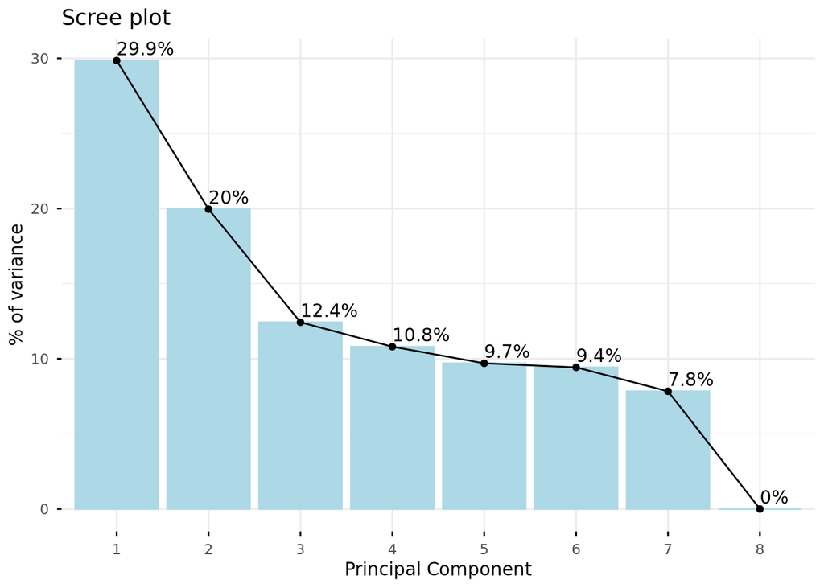

```r
# Perform a PCA on the matrix of normalized beta values generated in step 7 using the function prcomp().
pca_results <- prcomp(t(beta_preprocessQuantile), scale = TRUE)

# We use the fviz_eig function to create the scree plot
fviz_eig(pca_results, addlabels = TRUE, xlab = 'Principal Component', ylab = '% of variance', barfill = "lightblue", barcolor = "lightblue")
```

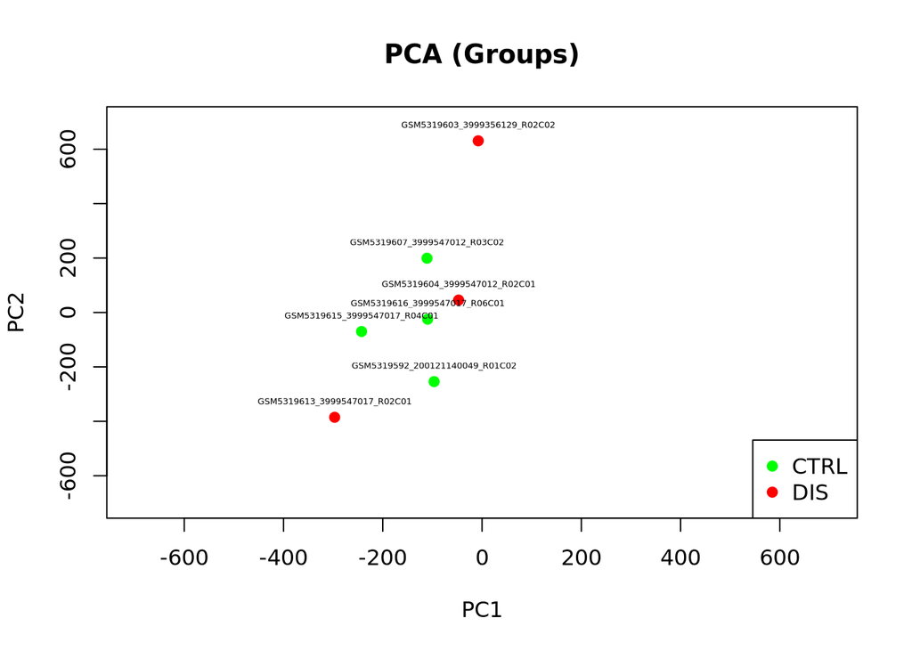

```r
# PCA plot per Group
targets$Group <- as.factor(targets$Group)
group_colors <- c("green", "red")
plot(pca_results$x[, 1], pca_results$x[, 2], cex = 1, pch = 19, col = group_colors[targets$Group], xlim = c(-700, 700), ylim = c(-700, 700), xlab = "PC1", ylab = "PC2", main = 'PCA (Groups)')
text(pca_results$x[, 1], pca_results$x[, 2], labels = rownames(pca_results$x), cex = 0.4, pos = 3)
legend("bottomright", legend = levels(targets$Group), col = group_colors, pch = 19, cex = 1.0)
```

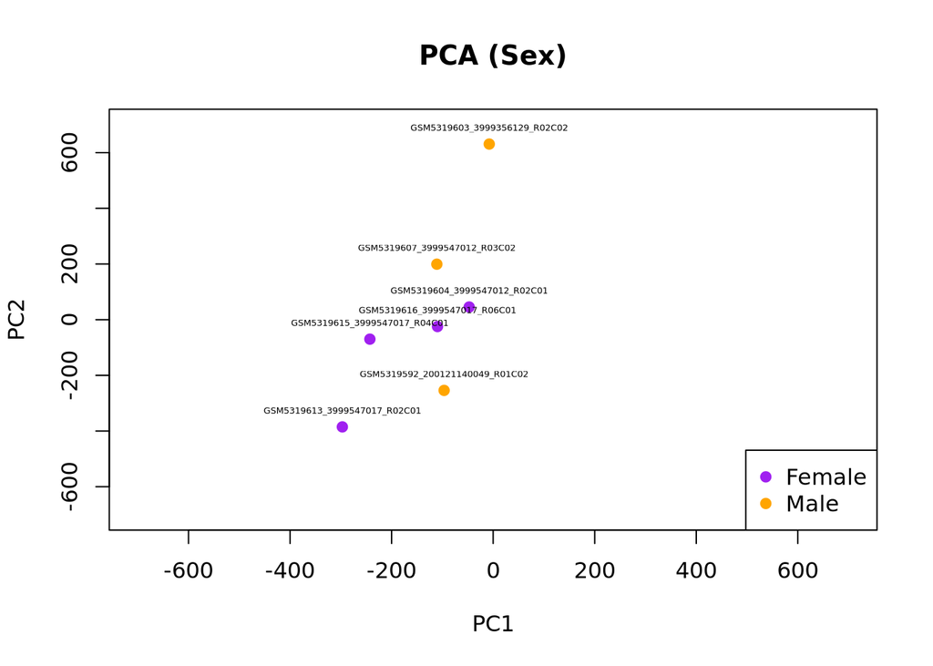

```r
# PCA plot per Sex
targets$Sex <- as.factor(targets$Sex)
sex_colors <- c("purple", "orange")
plot(pca_results$x[, 1], pca_results$x[, 2], cex = 1, pch = 19, col = sex_colors[targets$Sex], xlim = c(-700, 700), ylim = c(-700, 700), xlab = "PC1", ylab = "PC2", main = 'PCA (Sex)')
text(pca_results$x[, 1], pca_results$x[, 2], labels = rownames(pca_results$x), cex = 0.4, pos = 3)
legend("bottomright", legend = levels(targets$Sex), col = sex_colors, pch = 19, cex = 1.0)
```

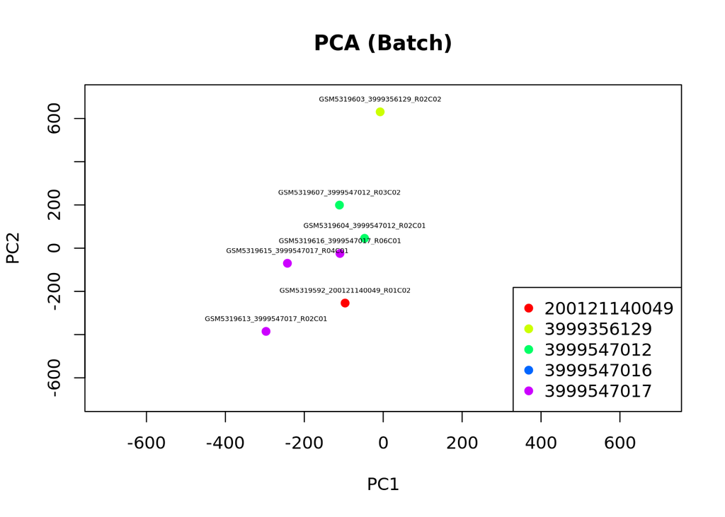

```r
# PCA plot colored by batch
targets$Slide <- as.factor(targets$Slide)
batch_colors <- rainbow(nlevels(targets$Slide))
plot(pca_results$x[, 1], pca_results$x[, 2], cex = 1, pch = 19, col = batch_colors[targets$Slide], xlim = c(-700, 700), ylim = c(-700, 700), xlab = "PC1", ylab = "PC2", main = "PCA (Batch)")
text(pca_results$x[, 1], pca_results$x[, 2], labels = rownames(pca_results$x), cex = 0.4, pos = 3)
legend("bottomright", legend = levels(targets$Slide), col = batch_colors, pch = 19, cex = 1.0)
```

### 9. Identification of differentially methylated probes using dmpFinder

We perform differential methylation analysis using the dmpFinder function from the minfi package to identify CpG probes that differ significantly between the CTRL and DIS groups. The analysis compares the normalized beta values between the two biological conditions through a probe-by-probe statistical test. Before running the test, any probes with missing values are removed to ensure the reliability of the results.The identified probes are then ranked based on their raw p-values, placing those with the strongest evidence of differential methylation at the top of the table. To understand the biological direction of these changes, we calculate the average beta value for each group and compute the Delta Beta ($\Delta\beta$) as the difference between DIS and CTRL means. This process generates a final summary table that highlights exactly which probes are hyper- or hypo-methylated in the disease group compared to the controls.

```r
# Prepare the normalized matrix and check dimensions
beta_preprocessQuantile_step9 <- beta_preprocessQuantile
dim(beta_preprocessQuantile_step9)
```

```
## [1] 485512      8
```

```r
# Define the categorical phenotype groups
targets$Group <- as.factor(targets$Group)
group_step9 <- targets$Group

# Safety checks before testing
stopifnot(ncol(beta_preprocessQuantile_step9) == nrow(targets))
stopifnot(length(group_step9) == ncol(beta_preprocessQuantile_step9))

# Remove probes containing missing values
beta_preprocessQuantile_step9_clean <- beta_preprocessQuantile_step9[complete.cases(beta_preprocessQuantile_step9), ]
dim(beta_preprocessQuantile_step9_clean)
```

```
## [1] 485512      8
```

```r
# Identify differentially methylated probes
dmp_preprocessQuantile <- dmpFinder(beta_preprocessQuantile_step9_clean, pheno = group_step9, type = "categorical")

# Order the table by raw p-value and extract identifiers
dmp_preprocessQuantile <- dmp_preprocessQuantile[order(dmp_preprocessQuantile$pval), ]
dmp_preprocessQuantile$CpG <- rownames(dmp_preprocessQuantile)

# Calculate group specific means
mean_beta_CTRL_step9 <- rowMeans(beta_preprocessQuantile_step9_clean[, group_step9 == "CTRL", drop = FALSE], na.rm = TRUE)
mean_beta_DIS_step9  <- rowMeans(beta_preprocessQuantile_step9_clean[, group_step9 == "DIS", drop = FALSE], na.rm = TRUE)

# Append mean profiles to the output dataset
dmp_preprocessQuantile$mean_beta_CTRL <- mean_beta_CTRL_step9[dmp_preprocessQuantile$CpG]
dmp_preprocessQuantile$mean_beta_DIS  <- mean_beta_DIS_step9[dmp_preprocessQuantile$CpG]

# Calculate biological effect direction (Delta Beta)
dmp_preprocessQuantile$deltaBeta <- dmp_preprocessQuantile$mean_beta_DIS - dmp_preprocessQuantile$mean_beta_CTRL

# Optimize column sequence layout
reordered_cols <- c("CpG", "mean_beta_CTRL", "mean_beta_DIS", "deltaBeta")
dmp_preprocessQuantile <- dmp_preprocessQuantile[, c(reordered_cols, setdiff(colnames(dmp_preprocessQuantile), reordered_cols))]

# Isolate and print the top 20 significant features
top20_dmp_preprocessQuantile <- head(dmp_preprocessQuantile, 20)
top20_dmp_preprocessQuantile
```

|  | CpG | mean_beta_CTRL | mean_beta_DIS | deltaBeta | intercept | f | pval | qval |
| --- | --- | --- | --- | --- | --- | --- | --- | --- |
| cg05289022 | cg05289022 | 0.7680796 | 0.3379385 | -0.43014107 | 0.7680796 | 660.1208 | 2.291486e-07 | 0.1033764 |
| cg07770777 | cg07770777 | 0.3915816 | 0.8094156 | 0.41783401 | 0.3915816 | 350.7406 | 1.496251e-06 | 0.2235940 |
| cg26612165 | cg26612165 | 0.0567207 | 0.0702892 | 0.01356850 | 0.0567207 | 292.4291 | 2.559069e-06 | 0.2235940 |
| cg25282454 | cg25282454 | 0.7165248 | 0.3994400 | -0.31708480 | 0.7165248 | 272.2053 | 3.160471e-06 | 0.2235940 |
| cg22191606 | cg22191606 | 0.4472594 | 0.5948876 | 0.14762822 | 0.4472594 | 257.2021 | 3.734079e-06 | 0.2235940 |
| cg13331196 | cg13331196 | 0.4646089 | 0.7072036 | 0.24259468 | 0.4646089 | 248.2980 | 4.141480e-06 | 0.2235940 |
| cg18077307 | cg18077307 | 0.6966244 | 0.2721525 | -0.42447194 | 0.6966244 | 243.4993 | 4.385831e-06 | 0.2235940 |
| cg11012965 | cg11012965 | 0.3307492 | 0.5868118 | 0.25606268 | 0.3307492 | 238.0310 | 4.688287e-06 | 0.2235940 |
| cg13754720 | cg13754720 | 0.6293997 | 0.8583659 | 0.22896625 | 0.6293997 | 230.6154 | 5.144560e-06 | 0.2235940 |
| cg23602058 | cg23602058 | 0.4044197 | 0.7845919 | 0.38017216 | 0.4044197 | 223.9194 | 5.608844e-06 | 0.2235940 |

[output cut: 10 more lines]

### 10. Apply multiple test correction and set significant threshold

In high-dimensional genomic analyses, testing hundreds of thousands of CpG probes simultaneously introduces a multiple testing problem, which drastically inflates the rate of false positive discoveries. To address this issue, we applied multiple testing corrections to the nominal p-values obtained from dmpFinder. Specifically, we computed adjusted p-values using two different statistical approaches: the Bonferroni correction, which strictly controls the Family-Wise Error Rate (FWER) but tends to be overly conservative, and the Benjamini-Hochberg (BH) method, which controls the False Discovery Rate (FDR) and provides higher statistical power. A conventional significance threshold of 0.05 was established. Finally, we calculated and compared the total number of significantly differentially methylated probes identified by each method (nominal p-value, Bonferroni, and BH) to assess how different stringency levels impact our final biological discoveries.

```r
# Calculate Bonferroni and Benjamini-Hochberg (BH) adjusted p-values
dmp_preprocessQuantile$pval_Bonferroni <- p.adjust(dmp_preprocessQuantile$pval, method = "bonferroni")
dmp_preprocessQuantile$pval_BH <- p.adjust(dmp_preprocessQuantile$pval, method = "BH")

# Set the significance threshold
threshold <- 0.05

# Count the number of significant probes for each method
sig_nominal <- sum(dmp_preprocessQuantile$pval < threshold)
sig_bonferroni <- sum(dmp_preprocessQuantile$pval_Bonferroni < threshold)
sig_BH <- sum(dmp_preprocessQuantile$pval_BH < threshold)

# Construct a summary table comparing the stringency of different multiple testing corrections
multiple_testing_summary <- data.frame(
  `Statistical Approach` = c("Nominal p-value (Unadjusted)", "Bonferroni Correction (FWER)", "Benjamini-Hochberg (BH/FDR)"),
  `Significant CpG Probes` = c(sig_nominal, sig_bonferroni, sig_BH),
  check.names = FALSE
)

# Display the final summary of differentially methylated loci across significance thresholds
multiple_testing_summary
```

| Statistical Approach | Significant CpG Probes |
| --- | --- |
| Nominal p-value (Unadjusted) | 20253 |
| Bonferroni Correction (FWER) | 0 |
| Benjamini-Hochberg (BH/FDR) | 0 |

### 11. Differential Methylation Analysis Visualization

To better interpret the results, we visualize the statistical outputs from dmpFinder using Volcano and Manhattan plots. The Volcano Plot shows the biological change on the x-axis (Delta Beta) against the statistical significance on the y-axis (-log10 p-value). By applying two thresholds—a horizontal red line for significance (p < 0.05) and vertical blue lines for a 10% methylation change (Delta Beta = +/- 0.10)—we can easily highlight the most relevant probes in red. This distribution clearly demonstrates that larger methylation differences are also the most statistically significant.

The Manhattan Plot, on the other hand, shows where these probes are located across the genome by combining p-values with their physical positions on the chromosomes. Chromosomes 1 to 22, X, and Y are arranged in order along the x-axis using alternating colors. Finally, a significance threshold line (p = 0.05) helps us see at a glance whether the methylation changes happen as isolated events or form dense clusters on specific chromosomes.

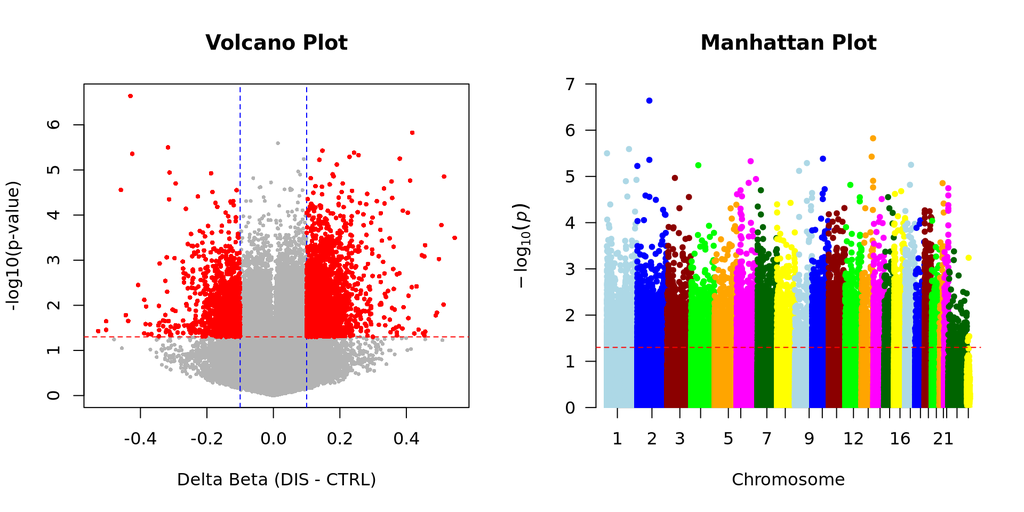

```r
# PRODUCE VOLCANO PLOT

# Isolate the normalized Beta values for each group and calculate their average profiles per probe
mean_ctrl <- apply(beta_preprocessQuantile_step9_clean[, targets$Group == "CTRL"], 1, mean, na.rm=TRUE)
mean_dis  <- apply(beta_preprocessQuantile_step9_clean[, targets$Group == "DIS"], 1, mean, na.rm=TRUE)

# Calculate the difference between the average methylation values (biological effect size)
delta <- mean_dis - mean_ctrl

# Match the probe order with the dmpFinder statistical output to ensure rows align correctly
delta_ordered <- delta[rownames(dmp_preprocessQuantile)]

# Create a dataframe with two columns: one for the delta values and the other for the -log10 of p-values
Volc_df <- data.frame(Delta = delta_ordered, NegLogP = -log10(dmp_preprocessQuantile$pval))

# Set layout to 1 row and 2 columns so the plots are side by side
par(mfrow = c(1, 2))

# Generate the base scatter plot for the Volcano Plot (cloud of grey dots)
plot(Volc_df$Delta, Volc_df$NegLogP, pch = 16, cex = 0.5, col = "grey70",
     xlab = "Delta Beta (DIS - CTRL)", ylab = "-log10(p-value)", main = "Volcano Plot")

# Add a horizontal significance threshold line at p-value = 0.05 and vertical threshold lines indicating a 10% difference in methylation (biological effect)
abline(h = -log10(0.05), col = "red", lty = 2)     # Significance threshold (p-value = 0.05)
abline(v = c(-0.1, 0.1), col = "blue", lty = 2)    # Biological threshold (Delta Beta = ±10%)

# Extract and isolate the statistically and biologically significant results and Highlight the significant probes on the plot by overlaying them in red
significant_features <- dmp_preprocessQuantile$pval < 0.05 & abs(delta_ordered) > 0.1
points(Volc_df$Delta[significant_features], Volc_df$NegLogP[significant_features], pch = 16, cex = 0.6, col = "red")


# PRODUCE MANHATTAN PLOT

# Merge statistical p-values with genomic coordinates from the manifest file
dmp_preprocessQuantile$IlmnID <- rownames(dmp_preprocessQuantile)
input_Manhattan <- merge(dmp_preprocessQuantile[, c("IlmnID", "pval")], Illumina450Manifest_clean[, c("IlmnID", "CHR", "MAPINFO")], by="IlmnID")

# Format and convert chromosomes (1-22, X, Y) into numbers for plot compatibility
order_chr <- c(1:22, "X", "Y")
input_Manhattan$CHR <- factor(input_Manhattan$CHR, levels=order_chr)
input_Manhattan$CHR <- as.numeric(input_Manhattan$CHR)

# Generate the Manhattan Plot and add a red significance threshold line
manhattan(input_Manhattan, snp="IlmnID", chr="CHR", bp="MAPINFO", p="pval",
          col=c("lightblue", "blue", "darkred", "green", "orange", "magenta", "darkgreen", "yellow"),
          main="Manhattan Plot", suggestiveline = FALSE, genomewideline = FALSE)
abline(h = -log10(0.05), col = "red", lty = 2)
```

```r
# Reset layout to default
par(mfrow = c (1,1))
```

### 12. Produce an heatmap of the top 100 significant, differentially methylated probes

To further explore the structure of the methylation data, hierarchical clustering heatmaps were generated using the 100 most significantly differentially methylated CpG probes identified by the statistical analysis. Restricting the analysis to the top-ranked loci reduces computational complexity while preserving the strongest biological signals. Beta values for these probes were arranged into a matrix and clustered using average-linkage hierarchical clustering on both rows (CpG sites) and columns (samples). Two heatmaps were produced, annotating samples either by disease status or by sex through colored side bars. These visualizations allow assessment of whether samples segregate according to the biological groups of interest and reveal patterns of similarity among both individuals and methylation markers.

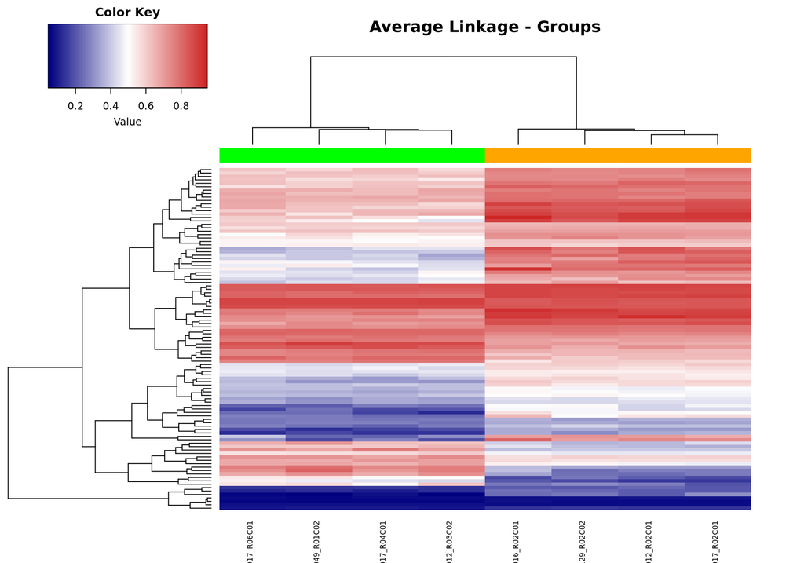

```r
# 1. We extract the IDs of the top 100 most significant probes
top100_probes <- dmp_preprocessQuantile$CpG[1:100]

# 2. We subset the normalized beta matrix to keep ONLY these 100 probes
input_heatmap <- as.matrix(beta_preprocessQuantile_step9_clean[top100_probes, ])

# 3. We create dynamic color bars based on the targets dataframe (Group: CTRL vs DIS)
colorbar_group <- ifelse(targets$Group == "CTRL", "green", "orange")

# Distance between clusters is found with average linkage mapping (GROUPS)
heatmap.2(input_heatmap,
          col = colorRampPalette(c("navy", "white", "firebrick3"))(100),
          Rowv = TRUE,
          Colv = TRUE,
          hclustfun = function(x) hclust(x, method = 'average'),
          dendrogram = "both",
          key = TRUE,
          ColSideColors = colorbar_group,
          density.info = "none",
          trace = "none",
          scale = "none",
          symm = FALSE,
          main = "Average Linkage - Groups",
          cexCol = 0.8,
          labRow = FALSE) # Hides probe IDs to make the heatmap cleaner
```

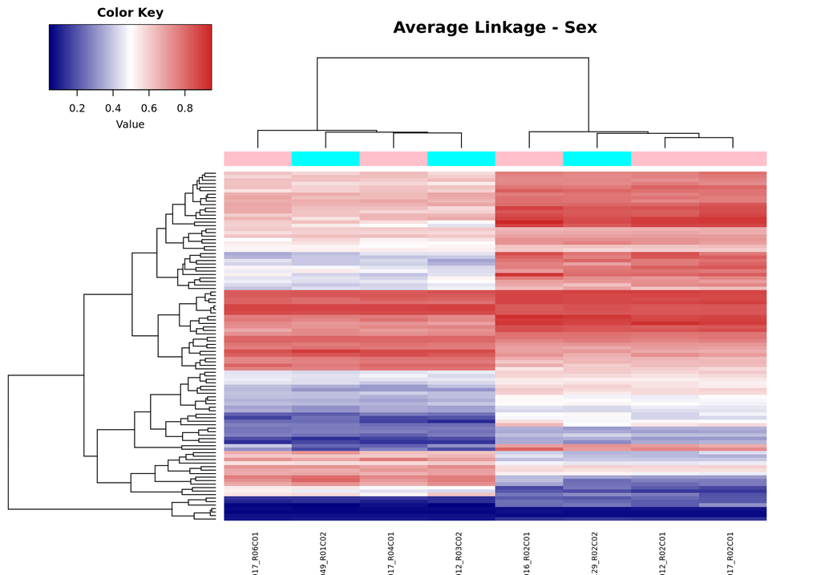

```r
# 4. We perform the analysis comparing sample using sex groups
# Robust check to handle both "Male"/"Female" and "M"/"F" formats in targets$Sex
colorbar_sex <- ifelse(targets$Sex %in% c("Male", "M"), "cyan",
                       ifelse(targets$Sex %in% c("Female", "F"), "pink", "grey"))

# Distance between clusters is found with average linkage mapping (SEX)
# Using the exact same color ramp palette to ensure scientific consistency
heatmap.2(input_heatmap,
          col = colorRampPalette(c("navy", "white", "firebrick3"))(100),
          Rowv = TRUE,
          Colv = TRUE,
          hclustfun = function(x) hclust(x, method = 'average'),
          dendrogram = "both",
          key = TRUE,
          ColSideColors = colorbar_sex,
          density.info = "none",
          trace = "none",
          scale = "none",
          symm = FALSE,
          main = "Average Linkage - Sex",
          cexCol = 0.8,
          labRow = FALSE)
```

The generated heatmaps show a clear picture of our samples methylation profiles. In the first heatmap (“Average Linkage - Groups”), the samples split perfectly into two main clusters that match the healthy controls (green) and disease samples (orange). This proves that the top 100 probes we selected carry a strong biological signal capable of separating the two conditions. In contrast, the second heatmap (“Average Linkage - Sex”) shows that males (cyan) and females (pink) are mixed randomly across the clusters. This confirms that our top 100 probes are specifically related to the disease status rather than being biased or driven by the sex of the individuals.